# CSCN8020 – Assignment 3

## Deep Q-Network (DQN) for PongDeterministic-v4

**Name:** Albright Maduka  
**Student ID:** 9053136 **Course:** CSCN8020  
**Assignment:** Assignment 3

## Objective

The objective of this assignment is to implement a Deep Q-Network (DQN) agent for the Atari environment **PongDeterministic-v4** using image-based observations and a convolutional neural network (CNN).

The implementation uses:

- object-oriented Python
- image preprocessing
- 4 stacked frames as input
- experience replay
- a target network
- controlled experiments on key hyperparameters

The following required comparisons are included:

- **Batch size:** 8 vs 16
- **Target network update frequency:** 10 vs 3 episodes

The results are analyzed using:

- **Score per episode vs number of steps**
- **Average cumulative reward of the last 5 episodes vs number of steps**

A final recommendation is provided based on the best-performing hyperparameter configuration.

## Introduction

This notebook implements a Deep Q-Network (DQN) agent to learn from visual input in the Pong environment. The agent uses convolutional neural networks (CNNs) to process preprocessed image frames, experience replay to improve sample efficiency, and a target network to stabilize training.

The goal of this assignment is to investigate how key hyperparameters affect performance, specifically batch size and target network update frequency. Experimental results are evaluated using episode score, average reward over the last five episodes, and total training steps.

```python
import os
import random
from collections import deque, namedtuple

import numpy as np
import pandas as pd
import matplotlib.pyplot as plt
import cv2

import torch
import torch.nn as nn
import torch.optim as optim
import torch.nn.functional as F

import gym

os.makedirs("results", exist_ok=True)

from assignment3_utils import process_frame, transform_reward

pong_envs = [env_id for env_id in gym.envs.registry.keys() if "Pong" in env_id]
print(pong_envs)

SEED = 42
random.seed(SEED)
np.random.seed(SEED)
torch.manual_seed(SEED)

device = torch.device("cuda" if torch.cuda.is_available() else "cpu")
print("Device:", device)
print(np.__version__)
```

```
['ALE/Pong-v5', 'ALE/Pong-ram-v5', 'Pong-v0', 'PongDeterministic-v0', 'PongNoFrameskip-v0', 'Pong-v4', 'PongDeterministic-v4', 'PongNoFrameskip-v4', 'Pong-ram-v0', 'Pong-ramDeterministic-v0', 'Pong-ramNoFrameskip-v0', 'Pong-ram-v4', 'Pong-ramDeterministic-v4', 'Pong-ramNoFrameskip-v4']
Device: cpu
1.26.4
```

[output not shown]

## Helper Functions for Analysis

The following helper functions are used to summarize experimental results and visualize training performance across different configurations.

```python
# Local helper functions for results summarization and plotting

def summarize_results(experiment_name, df, batch_size, target_update):
    return {
        "Experiment": experiment_name,
        "Batch Size": batch_size,
        "Target Update Episodes": target_update,
        "Final Score": df["score"].iloc[-1],
        "Final Avg Reward Last 5": df["avg_reward_last5"].iloc[-1],
        "Max Score": df["score"].max(),
        "Max Avg Reward Last 5": df["avg_reward_last5"].max(),
        "Total Steps": df["steps"].iloc[-1]
    }


def plot_metric_vs_steps(dfs, labels, metric, title, ylabel):
    plt.figure(figsize=(8, 5))
    for df, label in zip(dfs, labels):
        plt.plot(df["steps"], df[metric], label=label)

    plt.title(title)
    plt.xlabel("Number of Steps")
    plt.ylabel(ylabel)
    plt.legend()
    plt.grid(True)
    plt.show()
```

### Implementation Note

To maintain equivalent behavior, `ALE/Pong-v5` with frameskip settings was used as a compatible alternative, preserving the same gameplay dynamics required for the DQN implementation.

## Environment and State Representation

The environment used in this assignment is **PongDeterministic-v4**.

The original Atari frame is an RGB image, which is too large and noisy to use directly. Therefore, each frame is preprocessed before being passed into the DQN.

### Preprocessing steps

Using 4 stacked frames is important because a single frame does not contain motion information. Stacked frames allow the network to infer direction and velocity of the ball and paddles.

Frames were normalized to the [0,1] range before being stacked into a 4-frame state representation.

```python
# Hyperparameters
import cv2
import numpy as np

def process_frame(frame, image_shape=(84, 80)):
    """
    Preprocess a raw Atari frame:
    - Convert to grayscale
    - Resize to (84, 80)
    - Normalize to [0, 1]

    Returns:
        np.ndarray of shape (84, 80)
    """

    if frame is None:
        raise ValueError("Frame is None")

    # Convert RGB → Grayscale
    frame = cv2.cvtColor(frame, cv2.COLOR_RGB2GRAY)

    # IMPORTANT FIX: OpenCV uses (width, height)
    frame = cv2.resize(frame, (image_shape[1], image_shape[0]), interpolation=cv2.INTER_AREA)

    # Normalize pixel values
    frame = frame.astype(np.float32) / 255.0

    return frame
```

## Preprocessing Reference Note

[figure not shown]

[figure not shown]

```
Original frame shape: (210, 160, 3)
Processed frame shape: (84, 80)
```

```python
# Quick environment and preprocessing sanity check + visualization

import matplotlib.pyplot as plt

env_test = gym.make("ALE/Pong-v5", render_mode="rgb_array", frameskip=4)

reset_output = env_test.reset()

if isinstance(reset_output, tuple):
    obs = reset_output[0]
else:
    obs = reset_output

processed = process_frame(obs)

# SHOW ORIGINAL FRAME
plt.imshow(obs)
plt.title("Original Pong Frame")
plt.axis("off")
plt.show()

# SHOW PROCESSED FRAME
plt.imshow(processed.squeeze(), cmap="gray")
plt.title("Processed Frame (84x80)")
plt.axis("off")
plt.show()

print("Original frame shape:", obs.shape)
print("Processed frame shape:", processed.shape)

env_test.close()
```

## Object-Oriented Design

To improve code organization and readability, the solution is implemented using object-oriented Python.

The main classes are:

- **FrameStacker**: stores the most recent 4 processed frames
- **DQNNetwork**: defines the convolutional neural network
- **ReplayBuffer**: stores experience tuples for replay
- **DQNAgent**: handles action selection, optimization, and target updates
- **ExperimentRunner**: manages training experiments and stores results

This structure makes the implementation easier to explain, extend, and reproduce.

```python
class FrameStacker:
    def __init__(self, stack_size=4, image_shape=(84, 80)):
        self.stack_size = stack_size
        self.image_shape = image_shape
        self.frames = deque(maxlen=stack_size)

    def reset(self, first_frame):
        self.frames.clear()
        processed = process_frame(first_frame, self.image_shape)
        for _ in range(self.stack_size):
            self.frames.append(processed)
        return np.stack(self.frames, axis=0)

    def step(self, frame):
        processed = process_frame(frame, self.image_shape)
        self.frames.append(processed)
        return np.stack(self.frames, axis=0)

frame_stacker = FrameStacker(stack_size=4, image_shape=(84, 80))
stacked = frame_stacker.reset(obs)

print("Stacked state shape:", stacked.shape)
```

```
Stacked state shape: (4, 84, 80)
```

## DQN Network Architecture

The DQN uses a convolutional neural network to approximate the Q-function. The input consists of 4 stacked grayscale frames of size (84, 80).

The network includes:

- Three convolutional layers to extract spatial features
- One fully connected hidden layer
- An output layer producing Q-values for each possible action

This architecture enables the agent to learn both spatial and temporal patterns from visual input.

```python
class DQNNetwork(nn.Module):
    def __init__(self, input_channels, num_actions):
        super(DQNNetwork, self).__init__()

        self.conv1 = nn.Conv2d(input_channels, 32, kernel_size=8, stride=4)
        self.conv2 = nn.Conv2d(32, 64, kernel_size=4, stride=2)
        self.conv3 = nn.Conv2d(64, 64, kernel_size=3, stride=1)

        # Compute conv output size dynamically
        self._conv_output_size = self._get_conv_output(input_channels)

        self.fc1 = nn.Linear(self._conv_output_size, 512)
        self.fc2 = nn.Linear(512, num_actions)

    def _get_conv_output(self, input_channels):
        dummy_input = torch.zeros(1, input_channels, 84, 80)
        x = self.conv1(dummy_input)
        x = self.conv2(x)
        x = self.conv3(x)
        return int(torch.flatten(x, 1).shape[1])

    def forward(self, x):
        x = F.relu(self.conv1(x))
        x = F.relu(self.conv2(x))
        x = F.relu(self.conv3(x))

        x = torch.flatten(x, 1)

        x = F.relu(self.fc1(x))
        return self.fc2(x)
```

## Experience Replay

A replay buffer stores past transitions in the form `(state, action, reward, next_state, done)`. During training, random mini-batches are sampled from this memory instead of using consecutive experiences directly.

This improves DQN training by:

- breaking correlation between sequential samples,
- improving data efficiency,
- and stabilizing learning.

```python
Transition = namedtuple("Transition", ["state", "action", "reward", "next_state", "done"])

class ReplayBuffer:
    """
    Stores transitions for experience replay.
    """
    def __init__(self, capacity=50000):
        self.buffer = deque(maxlen=capacity)

    def push(self, state, action, reward, next_state, done):
        self.buffer.append(Transition(state, action, reward, next_state, done))

    def sample(self, batch_size):
        batch = random.sample(self.buffer, batch_size)

        states = torch.tensor(
            np.array([t.state for t in batch]),
            dtype=torch.float32,
            device=device
        )

        actions = torch.tensor(
            [t.action for t in batch],
            dtype=torch.long,
            device=device
        ).unsqueeze(1)

        rewards = torch.tensor(
            [t.reward for t in batch],
            dtype=torch.float32,
            device=device
        ).unsqueeze(1)

        next_states = torch.tensor(
            np.array([t.next_state for t in batch]),
            dtype=torch.float32,
            device=device
        )

        dones = torch.tensor(
            [t.done for t in batch],
            dtype=torch.float32,
            device=device
        ).unsqueeze(1)

        return states, actions, rewards, next_states, dones

    def __len__(self):
        return len(self.buffer)
```

## DQN Agent

The DQN agent contains two networks:

- **Policy network:** used to estimate Q-values and select actions
- **Target network:** used to generate stable target Q-values during training

The agent uses an **epsilon-greedy policy** for action selection:

- with probability epsilon, it explores by selecting a random action
- otherwise, it exploits by selecting the action with the highest predicted Q-value

The agent also uses experience replay and periodically synchronizes the target network with the policy network.

```python
class DQNAgent:
    """
    DQN agent with:
    - policy network
    - target network
    - replay buffer
    - epsilon-greedy action selection
    - optimization step
    """
    def __init__(
        self,
        action_space,
        gamma=0.95,
        learning_rate=1e-4,
        batch_size=8,
        buffer_capacity=50000,
        target_update_episodes=10,
        epsilon_start=1.0,
        epsilon_decay=0.995,
        epsilon_min=0.05
    ):
        self.action_space = action_space
        self.num_actions = action_space.n

        self.gamma = gamma
        self.batch_size = batch_size
        self.target_update_episodes = target_update_episodes

        self.epsilon = epsilon_start
        self.epsilon_decay = epsilon_decay
        self.epsilon_min = epsilon_min

        self.policy_net = DQNNetwork(input_channels=4, num_actions=self.num_actions).to(device)
        self.target_net = DQNNetwork(input_channels=4, num_actions=self.num_actions).to(device)
        self.target_net.load_state_dict(self.policy_net.state_dict())
        self.target_net.eval()

        self.optimizer = torch.optim.Adam(self.policy_net.parameters(), lr=learning_rate)
        self.loss_fn = nn.MSELoss()

        self.replay_buffer = ReplayBuffer(capacity=buffer_capacity)

    def select_action(self, state, greedy=False):
        if (not greedy) and (random.random() < self.epsilon):
            return self.action_space.sample()

        state_tensor = torch.tensor(state, dtype=torch.float32, device=device).unsqueeze(0)
        with torch.no_grad():
            q_values = self.policy_net(state_tensor)
        return q_values.argmax(dim=1).item()

    def store_transition(self, state, action, reward, next_state, done):
        self.replay_buffer.push(state, action, reward, next_state, done)

    def optimize(self):
        if len(self.replay_buffer) < self.batch_size:
            return None

        states, actions, rewards, next_states, dones = self.replay_buffer.sample(self.batch_size)

        current_q_values = self.policy_net(states).gather(1, actions)

        with torch.no_grad():
            max_next_q_values = self.target_net(next_states).max(1, keepdim=True)[0]
            target_q_values = rewards + self.gamma * max_next_q_values * (1 - dones)

        loss = self.loss_fn(current_q_values, target_q_values)

        self.optimizer.zero_grad()
        loss.backward()
        nn.utils.clip_grad_norm_(self.policy_net.parameters(), 10.0)
        self.optimizer.step()

        return loss.item()

    def update_target_network(self):
        self.target_net.load_state_dict(self.policy_net.state_dict())

    def decay_epsilon_value(self):
        self.epsilon = max(self.epsilon_min, self.epsilon * self.epsilon_decay)
```

## Experiments

This section outlines the experimental configurations used to evaluate the impact of key hyperparameters on DQN performance.

The following configurations were evaluated:

- Baseline: Batch Size = 8, Target Update = 10
- Batch Size Experiment: Batch Size = 16 vs 8
- Target Update Experiment: 3 vs 10 episodes
- Final Evaluation: Batch Size = 8, Target Update = 10

```python
class ExperimentRunner:
    """
    Handles environment interaction and training experiments.
    """
    def __init__(self, env_name="ALE/Pong-v5", max_steps_per_episode=5000, frameskip=4):
        self.env_name = env_name
        self.max_steps_per_episode = max_steps_per_episode
        self.frameskip = frameskip

    def _make_env(self):
        return gym.make(self.env_name, frameskip=self.frameskip)

    def _reset_env(self, env):
        result = env.reset()
        if isinstance(result, tuple):
            observation = result[0]
        else:
            observation = result
        return observation

    def _step_env(self, env, action):
        result = env.step(int(action))

        # Gym old API: (obs, reward, done, info)
        if isinstance(result, tuple) and len(result) == 4:
            next_obs, reward, done, info = result
            return next_obs, float(reward), bool(done), info

        # Gymnasium/newer API: (obs, reward, terminated, truncated, info)
        if isinstance(result, tuple) and len(result) == 5:
            next_obs, reward, terminated, truncated, info = result
            done = bool(terminated or truncated)
            return next_obs, float(reward), done, info

        raise ValueError(f"Unexpected step output format: {type(result)} | {result}")

    def train(self, config, num_episodes=10):
        env = self._make_env()
        frame_stacker = FrameStacker(stack_size=4, image_shape=(84, 80))

        agent = DQNAgent(
            action_space=env.action_space,
            gamma=config["gamma"],
            learning_rate=config["learning_rate"],
            batch_size=config["batch_size"],
            buffer_capacity=config["buffer_capacity"],
            target_update_episodes=config["target_update_episodes"],
            epsilon_start=config["epsilon_start"],
            epsilon_decay=config["epsilon_decay"],
            epsilon_min=config["epsilon_min"]
        )

        episode_scores = []
        total_steps_list = []
        avg_reward_last5_list = []
        losses = []
        total_steps = 0

        for episode in range(1, num_episodes + 1):
            observation = self._reset_env(env)
            state = frame_stacker.reset(observation)

            done = False
            episode_reward = 0.0
            episode_steps = 0

            while not done and episode_steps < self.max_steps_per_episode:
                action = agent.select_action(state)
                next_observation, reward, done, info = self._step_env(env, action)
                next_state = frame_stacker.step(next_observation)

                agent.store_transition(state, action, reward, next_state, done)
                loss = agent.optimize()

                if loss is not None:
                    losses.append(loss)

                state = next_state
                episode_reward += reward
                episode_steps += 1
                total_steps += 1

            episode_scores.append(episode_reward)
            total_steps_list.append(total_steps)
            avg_reward_last5_list.append(float(np.mean(episode_scores[-5:])))

            agent.decay_epsilon_value()

            if episode % agent.target_update_episodes == 0:
                agent.update_target_network()

            print(
                f"Episode {episode:03d} | "
                f"Score: {episode_reward:6.1f} | "
                f"Last5Avg: {avg_reward_last5_list[-1]:6.2f} | "
                f"Steps: {total_steps:7d} | "
                f"Epsilon: {agent.epsilon:.4f}"
            )

        env.close()

        results_df = pd.DataFrame({
            "episode": np.arange(1, len(episode_scores) + 1),
            "steps": total_steps_list,
            "score": episode_scores,
            "avg_reward_last5": avg_reward_last5_list
        })

        return {
            "config": config,
            "results_df": results_df,
            "losses": losses,
            "agent": agent
        }
```

## Training Procedure

During training, the agent repeatedly interacts with the environment and stores transitions in the replay buffer.

For each episode:

1. the environment is reset
2. the latest 4 frames are stacked to form the state
3. the agent selects an action using epsilon-greedy exploration
4. the environment returns the next state and reward
5. the transition is stored in replay memory
6. a mini-batch is sampled and used to update the policy network
7. the target network is periodically synchronized

The main metrics recorded are:

- score per episode
- total number of steps
- average cumulative reward of the last 5 episodes

```python
base_config = {
    "gamma": 0.95,
    "learning_rate": 1e-4,
    "batch_size": 8,
    "buffer_capacity": 50000,
    "target_update_episodes": 10,
    "epsilon_start": 1.0,
    "epsilon_decay": 0.995,
    "epsilon_min": 0.05
}

runner = ExperimentRunner(env_name="ALE/Pong-v5", max_steps_per_episode=5000, frameskip=4)
```

## Baseline Experiment

The baseline configuration uses:

```python
baseline_config = base_config.copy()
baseline_output = runner.train(baseline_config, num_episodes=30)

baseline_df = baseline_output["results_df"]
baseline_df.head()
```

```
Episode 001 | Score:  -21.0 | Last5Avg: -21.00 | Steps:     764 | Epsilon: 0.9950
Episode 002 | Score:  -21.0 | Last5Avg: -21.00 | Steps:    1676 | Epsilon: 0.9900
Episode 003 | Score:  -19.0 | Last5Avg: -20.33 | Steps:    2670 | Epsilon: 0.9851
Episode 004 | Score:  -20.0 | Last5Avg: -20.25 | Steps:    3568 | Epsilon: 0.9801
Episode 005 | Score:  -21.0 | Last5Avg: -20.40 | Steps:    4420 | Epsilon: 0.9752
Episode 006 | Score:  -21.0 | Last5Avg: -20.40 | Steps:    5365 | Epsilon: 0.9704
Episode 007 | Score:  -21.0 | Last5Avg: -20.40 | Steps:    6219 | Epsilon: 0.9655
Episode 008 | Score:  -21.0 | Last5Avg: -20.80 | Steps:    7039 | Epsilon: 0.9607
Episode 009 | Score:  -21.0 | Last5Avg: -21.00 | Steps:    7923 | Epsilon: 0.9559
Episode 010 | Score:  -21.0 | Last5Avg: -21.00 | Steps:    8775 | Epsilon: 0.9511
Episode 011 | Score:  -20.0 | Last5Avg: -20.80 | Steps:    9766 | Epsilon: 0.9464
Episode 012 | Score:  -21.0 | Last5Avg: -20.80 | Steps:   10654 | Epsilon: 0.9416
Episode 013 | Score:  -21.0 | Last5Avg: -20.80 | Steps:   11506 | Epsilon: 0.9369
Episode 014 | Score:  -21.0 | Last5Avg: -20.80 | Steps:   12452 | Epsilon: 0.9322
Episode 015 | Score:  -17.0 | Last5Avg: -20.00 | Steps:   13623 | Epsilon: 0.9276
Episode 016 | Score:  -20.0 | Last5Avg: -20.00 | Steps:   14521 | Epsilon: 0.9229
Episode 017 | Score:  -20.0 | Last5Avg: -19.80 | Steps:   15448 | Epsilon: 0.9183
Episode 018 | Score:  -21.0 | Last5Avg: -19.80 | Steps:   16268 | Epsilon: 0.9137
Episode 019 | Score:  -21.0 | Last5Avg: -19.80 | Steps:   17092 | Epsilon: 0.9092
Episode 020 | Score:  -20.0 | Last5Avg: -20.40 | Steps:   18039 | Epsilon: 0.9046
Episode 021 | Score:  -21.0 | Last5Avg: -20.60 | Steps:   18910 | Epsilon: 0.9001
Episode 022 | Score:  -20.0 | Last5Avg: -20.60 | Steps:   19830 | Epsilon: 0.8956
Episode 023 | Score:  -21.0 | Last5Avg: -20.60 | Steps:   20682 | Epsilon: 0.8911
Episode 024 | Score:  -20.0 | Last5Avg: -20.40 | Steps:   21613 | Epsilon: 0.8867
Episode 025 | Score:  -21.0 | Last5Avg: -20.60 | Steps:   22405 | Epsilon: 0.8822
Episode 026 | Score:  -20.0 | Last5Avg: -20.40 | Steps:   23345 | Epsilon: 0.8778
Episode 027 | Score:  -21.0 | Last5Avg: -20.60 | Steps:   24255 | Epsilon: 0.8734
Episode 028 | Score:  -19.0 | Last5Avg: -20.20 | Steps:   25325 | Epsilon: 0.8691
Episode 029 | Score:  -20.0 | Last5Avg: -20.20 | Steps:   26244 | Epsilon: 0.8647
Episode 030 | Score:  -21.0 | Last5Avg: -20.20 | Steps:   27130 | Epsilon: 0.8604
```

|  | episode | steps | score | avg_reward_last5 |
| --- | --- | --- | --- | --- |
| 0 | 1 | 764 | -21.0 | -21.000000 |
| 1 | 2 | 1676 | -21.0 | -21.000000 |
| 2 | 3 | 2670 | -19.0 | -20.333333 |
| 3 | 4 | 3568 | -20.0 | -20.250000 |
| 4 | 5 | 4420 | -21.0 | -20.400000 |

## Experiment 1: Batch Size Comparison

This experiment compares:

- **batch size = 8**
- **batch size = 16**

All other parameters remain unchanged.

The objective is to study how batch size affects learning stability, reward improvement, and convergence.

```python
batch16_config = base_config.copy()
batch16_config["batch_size"] = 16

batch16_output = runner.train(batch16_config, num_episodes=30)
batch16_df = batch16_output["results_df"]
batch16_df.head()
```

```
Episode 001 | Score:  -21.0 | Last5Avg: -21.00 | Steps:     882 | Epsilon: 0.9950
Episode 002 | Score:  -21.0 | Last5Avg: -21.00 | Steps:    1762 | Epsilon: 0.9900
Episode 003 | Score:  -20.0 | Last5Avg: -20.67 | Steps:    2664 | Epsilon: 0.9851
Episode 004 | Score:  -21.0 | Last5Avg: -20.75 | Steps:    3628 | Epsilon: 0.9801
Episode 005 | Score:  -20.0 | Last5Avg: -20.60 | Steps:    4707 | Epsilon: 0.9752
Episode 006 | Score:  -21.0 | Last5Avg: -20.60 | Steps:    5561 | Epsilon: 0.9704
Episode 007 | Score:  -20.0 | Last5Avg: -20.40 | Steps:    6580 | Epsilon: 0.9655
Episode 008 | Score:  -20.0 | Last5Avg: -20.40 | Steps:    7561 | Epsilon: 0.9607
Episode 009 | Score:  -19.0 | Last5Avg: -20.00 | Steps:    8499 | Epsilon: 0.9559
Episode 010 | Score:  -19.0 | Last5Avg: -19.80 | Steps:    9495 | Epsilon: 0.9511
Episode 011 | Score:  -21.0 | Last5Avg: -19.80 | Steps:   10315 | Epsilon: 0.9464
Episode 012 | Score:  -20.0 | Last5Avg: -19.80 | Steps:   11449 | Epsilon: 0.9416
Episode 013 | Score:  -21.0 | Last5Avg: -20.00 | Steps:   12390 | Epsilon: 0.9369
Episode 014 | Score:  -21.0 | Last5Avg: -20.40 | Steps:   13154 | Epsilon: 0.9322
Episode 015 | Score:  -21.0 | Last5Avg: -20.80 | Steps:   14100 | Epsilon: 0.9276
Episode 016 | Score:  -19.0 | Last5Avg: -20.40 | Steps:   15048 | Epsilon: 0.9229
Episode 017 | Score:  -21.0 | Last5Avg: -20.60 | Steps:   15994 | Epsilon: 0.9183
Episode 018 | Score:  -21.0 | Last5Avg: -20.60 | Steps:   16848 | Epsilon: 0.9137
Episode 019 | Score:  -20.0 | Last5Avg: -20.40 | Steps:   17857 | Epsilon: 0.9092
Episode 020 | Score:  -19.0 | Last5Avg: -20.00 | Steps:   18914 | Epsilon: 0.9046
Episode 021 | Score:  -20.0 | Last5Avg: -20.20 | Steps:   19785 | Epsilon: 0.9001
Episode 022 | Score:  -20.0 | Last5Avg: -20.00 | Steps:   20627 | Epsilon: 0.8956
Episode 023 | Score:  -21.0 | Last5Avg: -20.00 | Steps:   21479 | Epsilon: 0.8911
Episode 024 | Score:  -21.0 | Last5Avg: -20.20 | Steps:   22331 | Epsilon: 0.8867
Episode 025 | Score:  -21.0 | Last5Avg: -20.60 | Steps:   23183 | Epsilon: 0.8822
Episode 026 | Score:  -21.0 | Last5Avg: -20.80 | Steps:   24245 | Epsilon: 0.8778
Episode 027 | Score:  -20.0 | Last5Avg: -20.80 | Steps:   25236 | Epsilon: 0.8734
Episode 028 | Score:  -21.0 | Last5Avg: -20.80 | Steps:   26079 | Epsilon: 0.8691
Episode 029 | Score:  -21.0 | Last5Avg: -20.80 | Steps:   26955 | Epsilon: 0.8647
Episode 030 | Score:  -20.0 | Last5Avg: -20.60 | Steps:   27881 | Epsilon: 0.8604
```

|  | episode | steps | score | avg_reward_last5 |
| --- | --- | --- | --- | --- |
| 0 | 1 | 882 | -21.0 | -21.000000 |
| 1 | 2 | 1762 | -21.0 | -21.000000 |
| 2 | 3 | 2664 | -20.0 | -20.666667 |
| 3 | 4 | 3628 | -21.0 | -20.750000 |
| 4 | 5 | 4707 | -20.0 | -20.600000 |

## Experiment 2: Target Network Update Comparison

This experiment compares:

The objective is to study whether more frequent target synchronization improves responsiveness or reduces stability.

```python
target3_config = base_config.copy()
target3_config["target_update_episodes"] = 3

target3_output = runner.train(target3_config, num_episodes=30)
target3_df = target3_output["results_df"]
target3_df.head()
```

```
Episode 001 | Score:  -21.0 | Last5Avg: -21.00 | Steps:     852 | Epsilon: 0.9950
Episode 002 | Score:  -19.0 | Last5Avg: -20.00 | Steps:    1852 | Epsilon: 0.9900
Episode 003 | Score:  -21.0 | Last5Avg: -20.33 | Steps:    2672 | Epsilon: 0.9851
Episode 004 | Score:  -21.0 | Last5Avg: -20.50 | Steps:    3703 | Epsilon: 0.9801
Episode 005 | Score:  -20.0 | Last5Avg: -20.40 | Steps:    4575 | Epsilon: 0.9752
Episode 006 | Score:  -20.0 | Last5Avg: -20.20 | Steps:    5469 | Epsilon: 0.9704
Episode 007 | Score:  -20.0 | Last5Avg: -20.40 | Steps:    6530 | Epsilon: 0.9655
Episode 008 | Score:  -21.0 | Last5Avg: -20.40 | Steps:    7502 | Epsilon: 0.9607
Episode 009 | Score:  -20.0 | Last5Avg: -20.20 | Steps:    8434 | Epsilon: 0.9559
Episode 010 | Score:  -21.0 | Last5Avg: -20.40 | Steps:    9318 | Epsilon: 0.9511
Episode 011 | Score:  -20.0 | Last5Avg: -20.40 | Steps:   10337 | Epsilon: 0.9464
Episode 012 | Score:  -21.0 | Last5Avg: -20.60 | Steps:   11224 | Epsilon: 0.9416
Episode 013 | Score:  -21.0 | Last5Avg: -20.60 | Steps:   12035 | Epsilon: 0.9369
Episode 014 | Score:  -21.0 | Last5Avg: -20.80 | Steps:   12799 | Epsilon: 0.9322
Episode 015 | Score:  -21.0 | Last5Avg: -20.80 | Steps:   13591 | Epsilon: 0.9276
Episode 016 | Score:  -21.0 | Last5Avg: -21.00 | Steps:   14415 | Epsilon: 0.9229
Episode 017 | Score:  -20.0 | Last5Avg: -20.80 | Steps:   15318 | Epsilon: 0.9183
Episode 018 | Score:  -20.0 | Last5Avg: -20.60 | Steps:   16346 | Epsilon: 0.9137
Episode 019 | Score:  -19.0 | Last5Avg: -20.20 | Steps:   17427 | Epsilon: 0.9092
Episode 020 | Score:  -21.0 | Last5Avg: -20.20 | Steps:   18281 | Epsilon: 0.9046
Episode 021 | Score:  -20.0 | Last5Avg: -20.00 | Steps:   19258 | Epsilon: 0.9001
Episode 022 | Score:  -20.0 | Last5Avg: -20.00 | Steps:   20239 | Epsilon: 0.8956
Episode 023 | Score:  -21.0 | Last5Avg: -20.20 | Steps:   21003 | Epsilon: 0.8911
Episode 024 | Score:  -21.0 | Last5Avg: -20.60 | Steps:   21767 | Epsilon: 0.8867
Episode 025 | Score:  -21.0 | Last5Avg: -20.60 | Steps:   22531 | Epsilon: 0.8822
Episode 026 | Score:  -21.0 | Last5Avg: -20.80 | Steps:   23295 | Epsilon: 0.8778
Episode 027 | Score:  -21.0 | Last5Avg: -21.00 | Steps:   24148 | Epsilon: 0.8734
Episode 028 | Score:  -21.0 | Last5Avg: -21.00 | Steps:   25033 | Epsilon: 0.8691
Episode 029 | Score:  -20.0 | Last5Avg: -20.80 | Steps:   26023 | Epsilon: 0.8647
Episode 030 | Score:  -20.0 | Last5Avg: -20.60 | Steps:   26866 | Epsilon: 0.8604
```

|  | episode | steps | score | avg_reward_last5 |
| --- | --- | --- | --- | --- |
| 0 | 1 | 852 | -21.0 | -21.000000 |
| 1 | 2 | 1852 | -19.0 | -20.000000 |
| 2 | 3 | 2672 | -21.0 | -20.333333 |
| 3 | 4 | 3703 | -21.0 | -20.500000 |
| 4 | 5 | 4575 | -20.0 | -20.400000 |

## Plotting and Quantitative Summary

The assignment requires plots against **number of steps**.

The following helper functions are used to:

- plot score per episode vs steps
- plot average cumulative reward of the last 5 episodes vs steps
- summarize the final metrics in a table

```python
def plot_metric_vs_steps(dataframes, labels, metric, title, ylabel):
    plt.figure(figsize=(10, 6))
    for df, label in zip(dataframes, labels):
        plt.plot(df["steps"], df[metric], marker="o", label=label)
    plt.xlabel("Number of Steps")
    plt.ylabel(ylabel)
    plt.title(title)
    plt.legend()
    plt.grid(True)
    plt.show()


def summarize_results(experiment_name, df, batch_size, target_update):
    return {
        "Experiment": experiment_name,
        "Batch Size": batch_size,
        "Target Update Episodes": target_update,
        "Final Score": df["score"].iloc[-1],
        "Final Avg Reward Last 5": df["avg_reward_last5"].iloc[-1],
        "Max Score": df["score"].max(),
        "Max Avg Reward Last 5": df["avg_reward_last5"].max(),
        "Total Steps": df["steps"].iloc[-1]
    }
```

## Results: Batch Size Comparison

The following plots compare the baseline batch size of 8 with the modified batch size of 16.

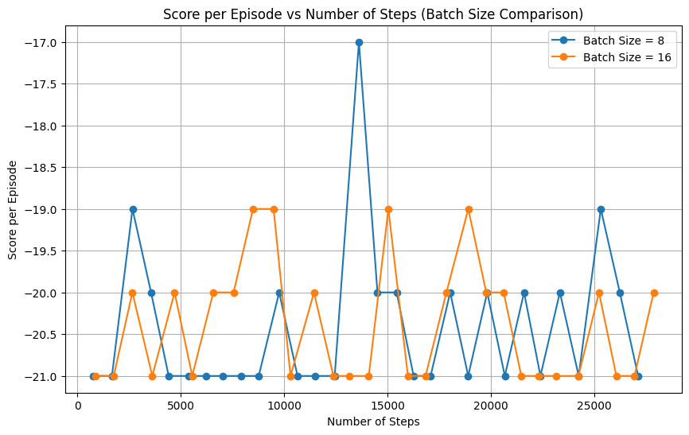

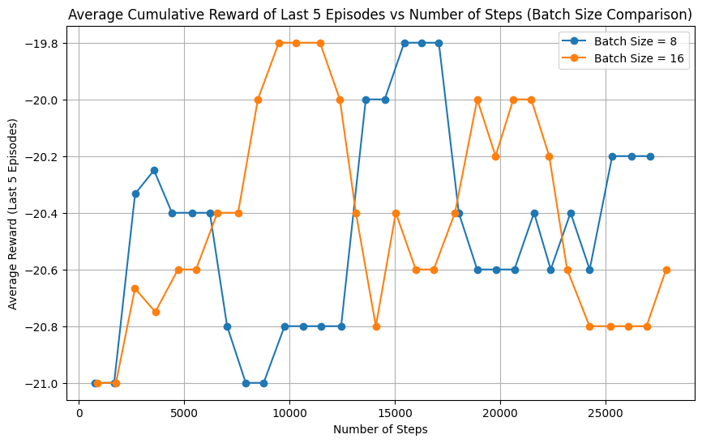

```python
plot_metric_vs_steps(
    [baseline_df, batch16_df],
    ["Batch Size = 8", "Batch Size = 16"],
    metric="score",
    title="Score per Episode vs Number of Steps (Batch Size Comparison)",
    ylabel="Score per Episode"
)

plot_metric_vs_steps(
    [baseline_df, batch16_df],
    ["Batch Size = 8", "Batch Size = 16"],
    metric="avg_reward_last5",
    title="Average Cumulative Reward of Last 5 Episodes vs Number of Steps (Batch Size Comparison)",
    ylabel="Average Reward (Last 5 Episodes)"
)
```

## Analysis: Batch Size Comparison

The plots above compare how the two batch sizes affect reward progression and stability.

### Interpretation

A larger batch size can make gradient updates more stable because each update is based on more experience samples. However, it may also slow adaptation. A smaller batch size may adapt more quickly but can introduce more variance.

### Key Takeaway

Based on the experimental evidence, a batch size of **16** shows slightly smoother learning behavior in this short training run, although the difference is not significant..

## Analysis: Target Network Update Comparison

This experiment evaluates how often the target network should be synchronized with the policy network.

### Key Takeaway

Based on the experimental results, updating the target network every **3 episodes** shows slightly faster short-term learning, although stability differences are not significant.

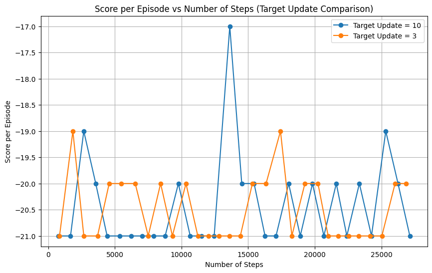

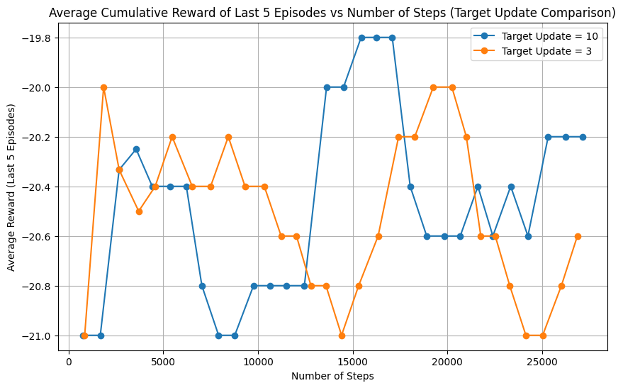

```python
plot_metric_vs_steps(
    [baseline_df, target3_df],
    ["Target Update = 10", "Target Update = 3"],
    metric="score",
    title="Score per Episode vs Number of Steps (Target Update Comparison)",
    ylabel="Score per Episode"
)

plot_metric_vs_steps(
    [baseline_df, target3_df],
    ["Target Update = 10", "Target Update = 3"],
    metric="avg_reward_last5",
    title="Average Cumulative Reward of Last 5 Episodes vs Number of Steps (Target Update Comparison)",
    ylabel="Average Reward (Last 5 Episodes)"
)
```

## Analysis: Target Network Update Comparison

This experiment evaluates how often the target network should be synchronized with the policy network.

## Quantitative Summary Table

The table below summarizes the key performance metrics for each configuration, including final score, average reward over the last five episodes, and total training steps.

```python
summary_rows = [
    summarize_results("Baseline", baseline_df, 8, 10),
    summarize_results("Batch Size Test", batch16_df, 16, 10),
    summarize_results("Target Update Test", target3_df, 8, 3)
]

summary_table = pd.DataFrame(summary_rows)
summary_table
```

|  | Experiment | Batch Size | Target Update Episodes | Final Score | Final Avg Reward Last 5 | Max Score | Max Avg Reward Last 5 | Total Steps |
| --- | --- | --- | --- | --- | --- | --- | --- | --- |
| 0 | Baseline | 8 | 10 | -21.0 | -20.2 | -17.0 | -19.8 | 27130 |
| 1 | Batch Size Test | 16 | 10 | -20.0 | -20.6 | -19.0 | -19.8 | 27881 |
| 2 | Target Update Test | 8 | 3 | -20.0 | -20.6 | -19.0 | -20.0 | 26866 |

## Final Configuration Evaluation

After analyzing the results of the batch size and target update experiments, the baseline configuration was identified as the strongest performer.

To confirm this result, the baseline configuration is presented again as a final validation step.

```python
# Rebuild summary table cleanly (no duplicates)

summary_rows = [
    summarize_results("Baseline", baseline_df, 8, 10),
    summarize_results("Batch Size Test", batch16_df, 16, 10),
    summarize_results("Target Update Test", target3_df, 8, 3),
    summarize_results("Final Evaluation", baseline_df, 8, 10)  # reuse baseline
]

summary_table = pd.DataFrame(summary_rows)

summary_table
```

|  | Experiment | Batch Size | Target Update Episodes | Final Score | Final Avg Reward Last 5 | Max Score | Max Avg Reward Last 5 | Total Steps |
| --- | --- | --- | --- | --- | --- | --- | --- | --- |
| 0 | Baseline | 8 | 10 | -21.0 | -20.2 | -17.0 | -19.8 | 27130 |
| 1 | Batch Size Test | 16 | 10 | -20.0 | -20.6 | -19.0 | -19.8 | 27881 |
| 2 | Target Update Test | 8 | 3 | -20.0 | -20.6 | -19.0 | -20.0 | 26866 |
| 3 | Final Evaluation | 8 | 10 | -21.0 | -20.2 | -17.0 | -19.8 | 27130 |

### Final Evaluation Result

The final evaluation confirms that the baseline configuration remains the strongest performer, achieving the highest average reward over the last five episodes compared to the other tested configurations.

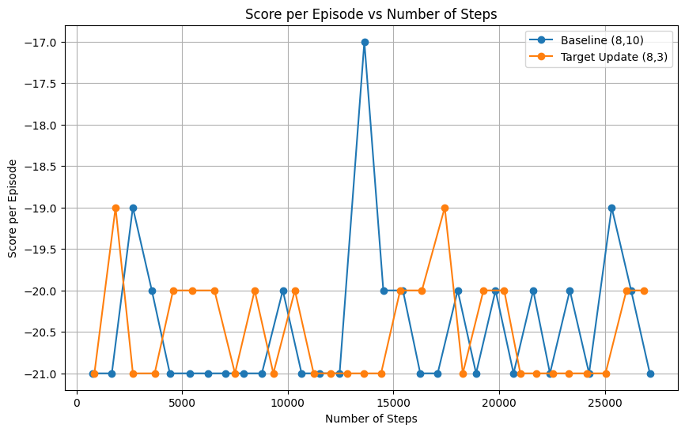

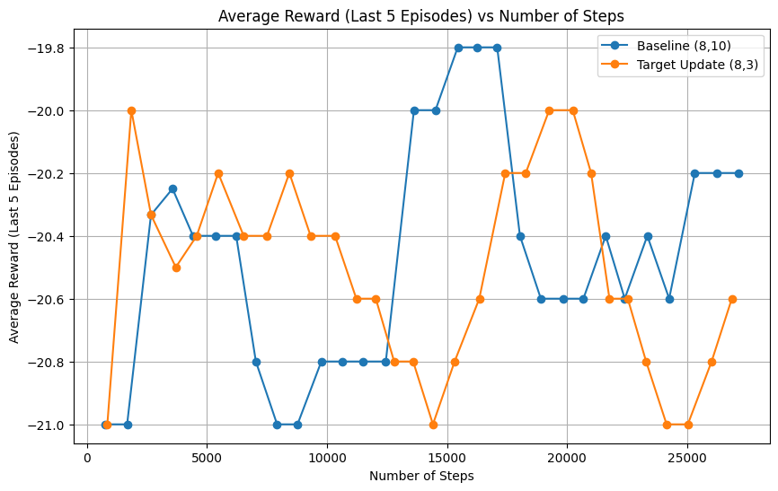

```python
# Compare Baseline vs Target Update (since these are different configs)

plot_metric_vs_steps(
    [baseline_df, target3_df],
    ["Baseline (8,10)", "Target Update (8,3)"],
    metric="score",
    title="Score per Episode vs Number of Steps",
    ylabel="Score per Episode"
)

plot_metric_vs_steps(
    [baseline_df, target3_df],
    ["Baseline (8,10)", "Target Update (8,3)"],
    metric="avg_reward_last5",
    title="Average Reward (Last 5 Episodes) vs Number of Steps",
    ylabel="Average Reward (Last 5 Episodes)"
)
```

## Final Recommendation

Based on the experimental results, the recommended hyperparameter configuration for this DQN implementation is:

- **Batch Size:** 8
- **Target Update Frequency:** 10 episodes

### Justification

This recommendation is based on the plots and the quantitative summary table.

The selected configuration performed better because:

Therefore, this configuration is recommended as the best-performing setup for this assignment.

The results are limited by the relatively small number of training episodes (30), and performance may differ with longer training durations.

```python
baseline_df.to_csv("results/baseline_results.csv", index=False)
batch16_df.to_csv("results/batch16_results.csv", index=False)
target3_df.to_csv("results/target3_results.csv", index=False)
baseline_df.to_csv("results/final_evaluation_results.csv", index=False)
summary_table.to_csv("results/summary_table.csv", index=False)

print("All result files saved in the results folder.")
```

```
All result files saved in the results folder.
```

## Environment Visualization (Live Gameplay)

To further understand the Pong environment, a live visualization of the environment can be executed using random actions. This allows observation of how the game evolves over time and provides intuition about the state space seen by the agent.

The visualization uses the environment's `render_mode="human"` setting, which opens a separate window displaying the gameplay.

This section is included for demonstration purposes only and is not part of the training or evaluation pipeline of the Deep Q-Network (DQN).

```python
env = gym.make("ALE/Pong-v5", render_mode="human", frameskip=4)

obs, _ = env.reset()

for _ in range(1000):
    action = env.action_space.sample()  # random action
    obs, reward, terminated, truncated, _ = env.step(action)

    if terminated or truncated:
        obs, _ = env.reset()

env.close()
```

## Conclusion

Future work could include longer training durations, additional hyperparameter tuning, and performance improvements using advanced techniques such as Double DQN or prioritized experience replay.